# پروژه ی تحلیل رگرسیون

امیرمحمد محمدقلیها 96100277

# Classification

توضیحات مختصر مربوط به هر ستون داده به صورت زیر است:

GRE Scores ( out of 340 )

نمره ی آزمون GRE

TOEFL Scores ( out of 120 )

نمره ی آزمون Tofel

University Rating ( out of 5 )

رتبه یا rate دانشگاه

Statement of Purpose Strength (SOR) ( out of 5 )

قوی بودن انگیزه ی فرد

Letter of Recommendation Strength (LOR) ( out of 5 )

قوی بودن recommendation های فرد

Undergraduate GPA (CGPA) ( out of 10 )

معدل کارشناسی

Research Experience ( either 0 or 1 )

تجربه ی تحقیق و research

Chance of Admit ( ranging from 0 to 1 )

شانس پذیرفته شدن

Admit (either 0 or 1)

پذیرفته شدن یا نشدن (که جلوتر آن را میسازیم).

حدود داده ها به صورت زیر است:

```r
summary(admission)
```

```
##    Serial No.      GRE Score      TOEFL Score    University Rating
##  Min.   :  1.0   Min.   :290.0   Min.   : 92.0   Min.   :1.000
##  1st Qu.:100.8   1st Qu.:308.0   1st Qu.:103.0   1st Qu.:2.000
##  Median :200.5   Median :317.0   Median :107.0   Median :3.000
##  Mean   :200.5   Mean   :316.8   Mean   :107.4   Mean   :3.087
##  3rd Qu.:300.2   3rd Qu.:325.0   3rd Qu.:112.0   3rd Qu.:4.000
##  Max.   :400.0   Max.   :340.0   Max.   :120.0   Max.   :5.000
##       SOP           LOR             CGPA          Research
##  Min.   :1.0   Min.   :1.000   Min.   :6.800   Min.   :0.0000
##  1st Qu.:2.5   1st Qu.:3.000   1st Qu.:8.170   1st Qu.:0.0000
##  Median :3.5   Median :3.500   Median :8.610   Median :1.0000
##  Mean   :3.4   Mean   :3.453   Mean   :8.599   Mean   :0.5475
##  3rd Qu.:4.0   3rd Qu.:4.000   3rd Qu.:9.062   3rd Qu.:1.0000
##  Max.   :5.0   Max.   :5.000   Max.   :9.920   Max.   :1.0000
##  Chance of Admit
##  Min.   :0.3400
##  1st Qu.:0.6400
##  Median :0.7300
##  Mean   :0.7244
##  3rd Qu.:0.8300
##  Max.   :0.9700
```

## Task

در اینجا قصد داریم پذیرفته شدن یا نشدن فرد را با استفاده از اطلاعات تحصیلی او پیش بینی کنیم. این کار به برنامه ریزی فرد بسیار میتواند کمک کننده باشد تا بداند در چه بخش های سرمایه گذاری بیشتری انجام دهد تا در آزمون پذیرفته شود.

متغیر هدف: Admit

ابتدا نمودار جعبه ای داده ها رسم میکنیم تا پراکندگی داده ها را بررسی کنیم.

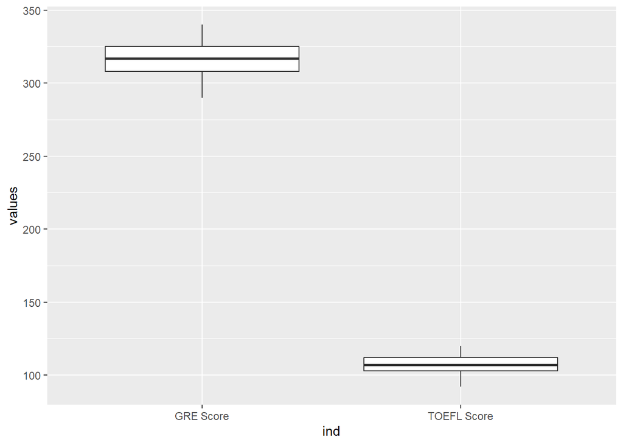

```r
# before dropping the outliers
ggplot(stack(admission[,2:3]),aes(x=ind,y=values))+geom_boxplot()
```

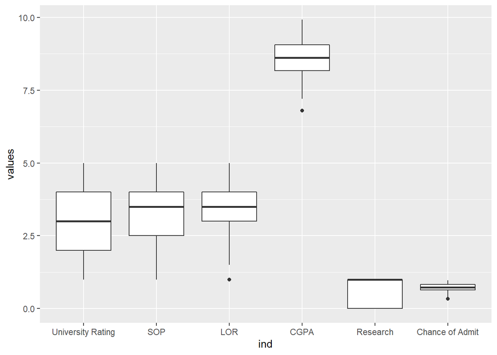

```r
ggplot(stack(admission[,4:9]),aes(x=ind,y=values))+geom_boxplot()
```

در ابتدا ستون اول که مربوط به شماره ی سریال است را حذف میکنیم زیرا اطلاعاتی از آن نمیتوان بدست آورد. سپس با استفاده از z-score داده های پرت را تبدیل به NA کرده تا هنگام حذف NA های داده، تمام داده های پرت حذف گردند.

```r
# omit the first column (Serial No.) which has no information
admission=admission[-which(colnames(admission)=="Serial No.") ]

# remove outliers using z-score
scaled=scale(admission, center = TRUE, scale = TRUE)
scaled=as.data.frame(scaled)
admission[abs(scaled)>3]=NA

# remove NA from dataset
admission=na.omit(admission)
```

اکنون باری دیگر به نمودار جعبه ای داده ها پس از حذف داده های پرت نگاهی میندازیم.

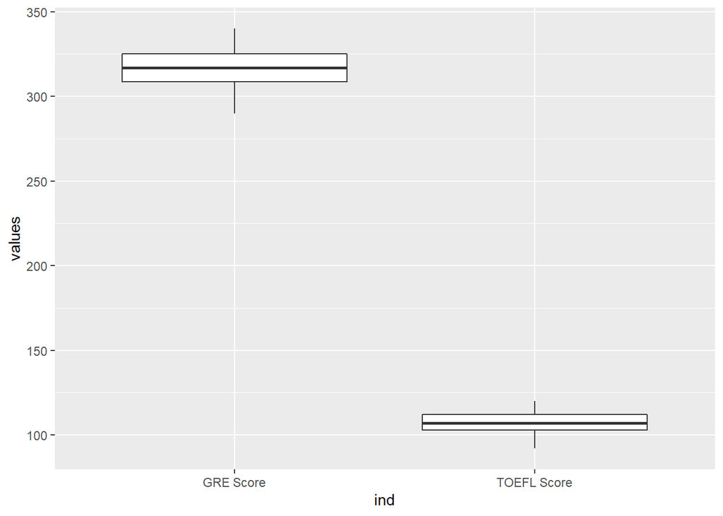

```r
# after dropping the outliers
ggplot(stack(admission[,1:2]),aes(x=ind,y=values))+geom_boxplot()
```

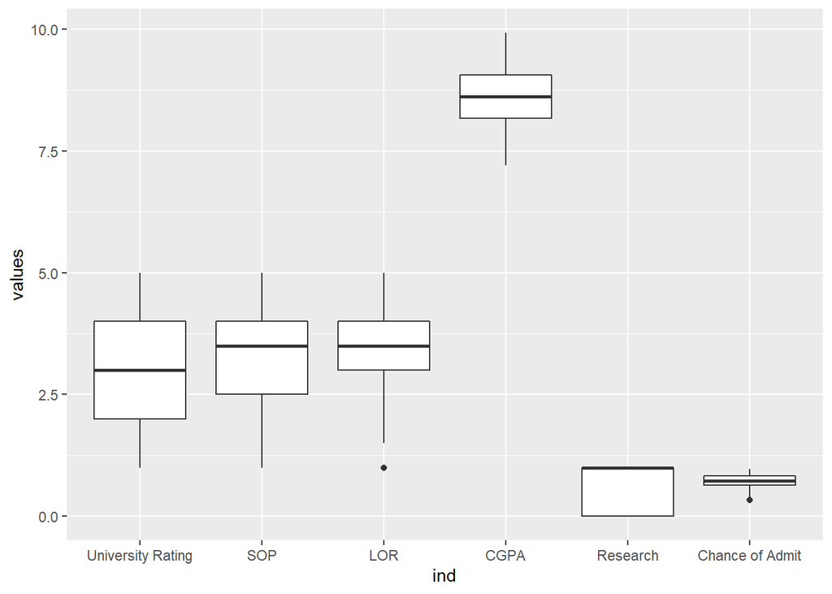

```r
ggplot(stack(admission[,3:8]),aes(x=ind,y=values))+geom_boxplot()
```

اکنون برای آنکه متغیر هدف یک کتغیر کیفی باشد، با در نظر گرفتن treshold برابر با 0.75 برای متغیر Chance of Admit یک متغیر dummy به نام Admit تعریف کرده ایم تا احتمال های بیشتر از حد تعیین شده را 1 و احتمال های کمتر از حد تعیین شده را 0 در نظر بگیریم.

```r
admission$Research=as.factor(admission$Research)

admission[admission$`Chance of Admit` >=0.75,"Admit"]=1
admission[admission$`Chance of Admit` <0.75,"Admit"]=0
admission$Admit=as.factor(admission$Admit)

#drop the (Chance of Admit) probability column
admission=admission[-which(colnames(admission)=="Chance of Admit") ]
```

```r
summary(admission)
```

```
##    GRE Score      TOEFL Score    University Rating      SOP
##  Min.   :290.0   Min.   : 92.0   Min.   :1.000     Min.   :1.000
##  1st Qu.:308.5   1st Qu.:103.0   1st Qu.:2.000     1st Qu.:2.500
##  Median :317.0   Median :107.0   Median :3.000     Median :3.500
##  Mean   :316.8   Mean   :107.4   Mean   :3.093     Mean   :3.401
##  3rd Qu.:325.0   3rd Qu.:112.0   3rd Qu.:4.000     3rd Qu.:4.000
##  Max.   :340.0   Max.   :120.0   Max.   :5.000     Max.   :5.000
##       LOR             CGPA       Research Admit
##  Min.   :1.000   Min.   :7.200   0:181    0:219
##  1st Qu.:3.000   1st Qu.:8.175   1:218    1:180
##  Median :3.500   Median :8.620
##  Mean   :3.456   Mean   :8.603
##  3rd Qu.:4.000   3rd Qu.:9.065
##  Max.   :5.000   Max.   :9.920
```

اکنون مشتاق هستیم تا میزان همبستگی بین متغیر ها را با بهره گیری از نمودار و شکل بررسی کنیم.

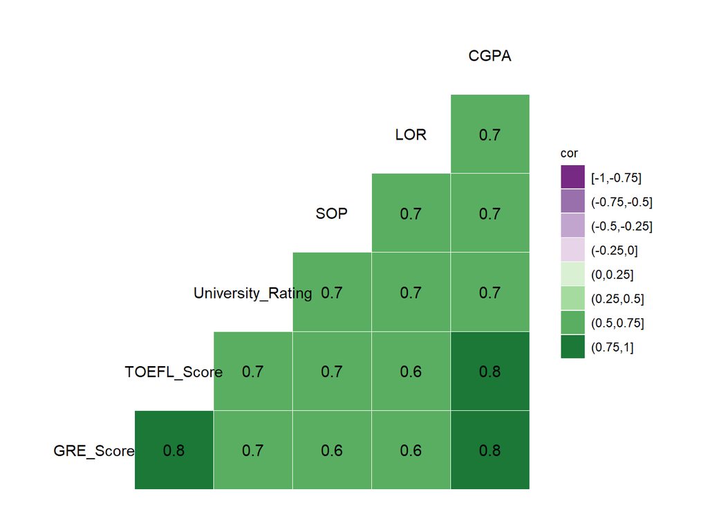

```r
ggcorr(admission, palette = "PRGn", name="cor",label=TRUE,nbreaks = 8)
```

میبینیم که همبستگی زیادی بین ستون ها هست و احتمالا افرادی که در تحصیلات خود موفق بوده اند، قوی بودنشان در تمام زمینه های تحصیلی به چشم میخورد.

یکی از راه های از بین بردن این همیستگی استفاده از PCA است.

```r
pca=prcomp(admission[,1:6],scale = TRUE)
summary(pca)
```

```
## Importance of components:
##                          PC1    PC2     PC3     PC4     PC5     PC6
## Standard deviation     2.124 0.7897 0.56007 0.49274 0.40403 0.38063
## Proportion of Variance 0.752 0.1040 0.05228 0.04047 0.02721 0.02415
## Cumulative Proportion  0.752 0.8559 0.90818 0.94865 0.97585 1.00000
```

میبینیم که واریانس نسبی تجمعی تا متغیر 4 ام حدود 95٪ است پس توقع داریم که بتوانیم مدل ها را با چهار متغیر توضیح دهنده برازش دهیم.

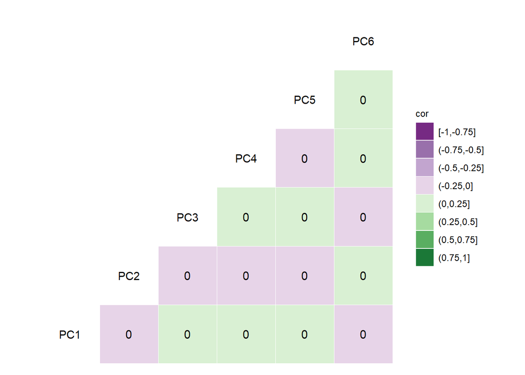

```r
loadings=as.data.frame(pca$x)
ggcorr(loadings, palette = "PRGn", name="cor",label=TRUE,nbreaks = 8)
```

```r
admission=cbind(loadings,admission[,7:8])
```

حال شش ستون جدید یعنی PC1 تا PC6 و Admit و Research را به یکدیگر میچسبانیم تا dataframe جدید تولید شود و اکنون با این داده ها کار میکنیم.

```r
pca=prcomp(admission[,1:6],scale = TRUE)
summary(pca)
```

```
## Importance of components:
##                           PC1    PC2    PC3    PC4    PC5    PC6
## Standard deviation     1.0000 1.0000 1.0000 1.0000 1.0000 1.0000
## Proportion of Variance 0.1667 0.1667 0.1667 0.1667 0.1667 0.1667
## Cumulative Proportion  0.1667 0.3333 0.5000 0.6667 0.8333 1.0000
```

## مدل GLM

```r
glmModel=glm(Admit~.,data=admission,family = binomial)
#summary(model)
glmProb=predict(glmModel,type = "response")
glmPred=c()
Admit=admission$Admit
glmPred[glmProb>=0.75]=1
glmPred[glmProb<0.75]=0

tableA=table(glmPred,Admit )
tableA
```

```
##        Admit
## glmPred   0   1
##       0 208  45
##       1  11 135
```

```r
accuracy=mean(glmPred==Admit)
accuracy
```

```
## [1] 0.8596491
```

```r
truePositive=tableA[2,2]
truePositive
```

```
## [1] 135
```

```r
falsePositive=tableA[2,1]
falsePositive
```

```
## [1] 11
```

```r
trueNegative=tableA[1,1]
trueNegative
```

```
## [1] 208
```

```r
falseNegative=tableA[1,2]
falseNegative
```

```
## [1] 45
```

در اینجا هردو خطا اهمیت دارند ولی خطای falseNegative ممکن است زیان بیشتری برساند یعنی به اشتباه پیش بینی کنیم که فرد در آزمون مردود خواهد شد. در این حالت ممکن است فرد نا امید شود و در پذیرش شرکت نکند. که با این استدلال ما در پی آن خواهیم بود که مقدار recall را افزایش دهیم. زیرا recall طبق فرمول زیر falseNegative را به صورت نسبی میسنجد. گرچه ممکن است برای برخی نیز falsePositive زیان آور تر به نظر آید که در این حالت شاخص precision را باید افزایش دهیم.

$$precision=\frac{true Positive}{true positive + false positive}$$

$$recall=\frac{true Positive}{true positive + false negative}$$

```r
precision=truePositive/(truePositive+falsePositive)
precision
```

```
## [1] 0.9246575
```

```r
recall=truePositive/(truePositive+falseNegative)
recall
```

```
## [1] 0.75
```

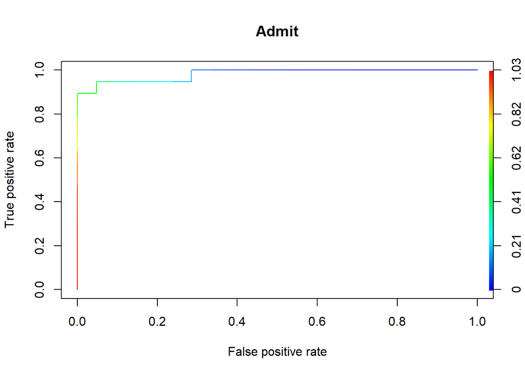

```r
indexes=sample(nrow(admission) ,replace = FALSE)
foldsIndexes = cut(indexes , breaks=10 , labels=FALSE)
indexesOfTest = which(foldsIndexes==1 , arr.ind=TRUE)
trainData=admission[-indexesOfTest,]
testData=admission[indexesOfTest,]

model=glm(Admit~.,data=trainData,family=binomial)
glmProb=predict(glmModel,testData,type = "response")
pred = prediction(glmProb, testData$Admit)
perf = performance(pred,"tpr","fpr")
plot(perf,colorize=TRUE,main="Admit")
```

## مدل KNN

```r
set.seed(100)
#we choose 80% of data as train and the rest as test
nrowTrainData=nrow(admission)*80/100
nrowTestData=nrow(admission)-nrowTrainData

indexOfDataTrain=sample(1:nrow(admission),nrowTrainData)

trainData=admission[indexOfDataTrain,]
testData=admission[-indexOfDataTrain,]

accuracy=c()
for (i in 1:20) {
knnModel=knn(train = trainData,test = testData,trainData$Admit,k=i)
accuracy[i]=(sum(testData$Admit==knnModel)/nrowTestData)
}
#vector of accuracy in term of each k
accuracy
```

```
##  [1] 0.9649123 0.9523810 0.9649123 0.9649123 0.9523810 0.9523810 0.9398496
##  [8] 0.9523810 0.9523810 0.9649123 0.9398496 0.9523810 0.9523810 0.9273183
## [15] 0.9523810 0.9649123 0.9649123 0.9649123 0.9649123 0.9523810
```

```r
#maximum accuracy
max(accuracy)
```

```
## [1] 0.9649123
```

```r
#maximum accuracy occures with following k
match(max(accuracy),accuracy)
```

```
## [1] 1
```

همانطور که میبینیم به ازای k=1 مقدار accuracy بیشینه شده است. اما accuracy تنها ملاک نیست و گاهی precision و recall نیز برای بهبود مدل کارآمد تر اند. شاخص accuracy زمانی مناسب است که تقارنی در جدول وجود داشته باشد. یعنی falsePositive و falseNegative تقریبا مقدار مشابهی داشته باشند. ابتدا برای مدل k=1 مقادیر زیر را محاسبه میکنیم:

```r
set.seed(100)
bestknn=knn(train = trainData,test = testData,trainData$Admit,k=1)
Admit=testData$Admit
tableA=table(bestknn,Admit)
tableA
```

```
##        Admit
## bestknn  0  1
##       0 48  1
##       1  2 29
```

```r
truePositive=sum(testData$Admit==1 & testData$Admit==bestknn)
truePositive
```

```
## [1] 29
```

```r
falsePositive=sum(testData$Admit==0 & testData$Admit!=bestknn)
falsePositive
```

```
## [1] 2
```

```r
trueNegative=sum(testData$Admit==0 & testData$Admit==bestknn)
trueNegative
```

```
## [1] 48
```

```r
falseNegative=sum(testData$Admit==1 & testData$Admit!=bestknn)
falseNegative
```

```
## [1] 1
```

```r
precision=truePositive/(truePositive+falsePositive)
precision
```

```
## [1] 0.9354839
```

```r
recall=truePositive/(truePositive+falseNegative)
recall
```

```
## [1] 0.9666667
```

```r
accuracy=sum(testData$Admit==bestknn)/nrowTestData
accuracy
```

```
## [1] 0.9649123
```

میبینیم که مقدار recall و precision هردو بهبود یافتند. پس مدل KNN مناسب تر از مدل Logistic است.

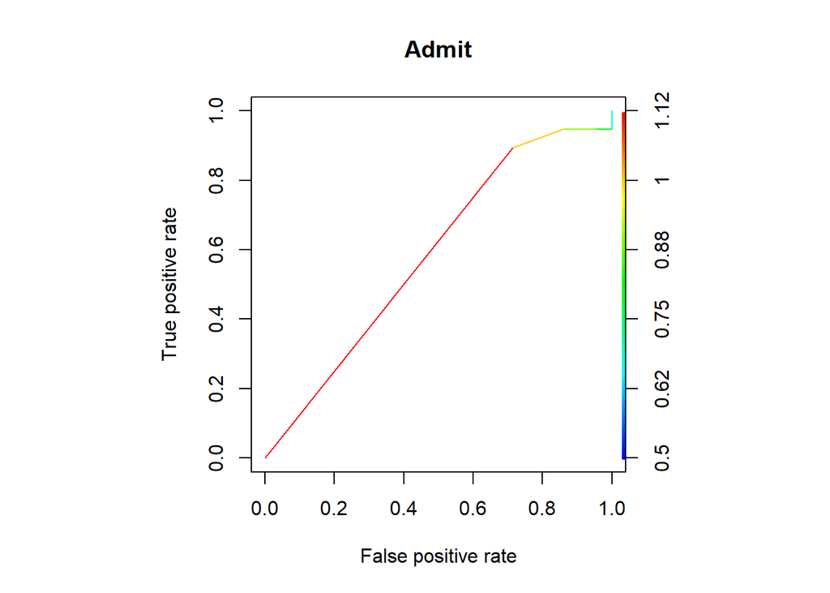

```r
indexes=sample(nrow(admission) ,replace = FALSE)
foldsIndexes = cut(indexes , breaks=10 , labels=FALSE)
indexesOfTest = which(foldsIndexes==1 , arr.ind=TRUE)
trainData=admission[-indexesOfTest,]
testData=admission[indexesOfTest,]

str=paste0("class",i)
trainResponse=admission$Admit[-indexesOfTest]
testResponse=admission$Admit[indexesOfTest]
cl = trainResponse[,drop=TRUE]
model= knn(trainData, testData, cl, k=10, prob=TRUE)
prob = attr(model, "prob")
pred = prediction(prob, testResponse)
perf = performance(pred,"tpr","fpr")
par(pty="s")
plot(perf,colorize=TRUE,main="Admit")
```

## مدل LDA

حال یک مدل lda به داده ها برازش میدهیم.

```r
ldaModel=lda(Admit~.,data=admission,subset=indexOfDataTrain)
ldaModel
```

```
## Call:
## lda(Admit ~ ., data = admission, subset = indexOfDataTrain)
##
## Prior probabilities of groups:
##         0         1
## 0.5297806 0.4702194
##
## Group means:
##         PC1         PC2          PC3         PC4         PC5          PC6
## 0  1.430367 -0.11129163 -0.005238275 0.006063242 -0.00862079  0.007786459
## 1 -1.806124  0.04997214 -0.018938411 0.005027845  0.02560699 -0.017065001
##   Research1
## 0 0.3017751
## 1 0.8200000
##
## Coefficients of linear discriminants:
##                   LD1
## PC1       -0.67515878
## PC2        0.20497834
## PC3        0.12227655
## PC4       -0.02505001
## PC5        0.18252004
## PC6       -0.37814140
## Research1  0.49703659
```

برای آزمودن این مدل از Cross Valodation k-fold استفاده میکنیم که تابع آن به صورت زیر تعریف میشود.

```r
ldaCrossValidation=function(df,ldaModel,k){
  set.seed(100)
  indexes=sample(nrow(df) ,replace = FALSE)
  foldsIndexes = cut(indexes , breaks=k , labels=FALSE)
  accuracy=c()
  myFormula=formula(paste(format(terms(ldaModel)),collapse = ""))

  myResponse=(as.character(attr(terms(myFormula),"variables"))[-1])[attr(terms(myFormula),"response")]
  myResponse=str_replace_all(myResponse ,"`","")
  for (i in 1:k) {
   indexesOfTest = which(foldsIndexes==i , arr.ind=TRUE)
   trainData=df[-indexesOfTest,]
   testData=df[indexesOfTest,]
   myModel=lda(formula = myFormula ,data = trainData )
   myPred=predict(ldaModel,testData)
    accuracy[i]=sum(myPred$class==testData$Admit)/dim(testData)[1]
  }
  output=mean(accuracy)
  return(output)
}
```

```r
ldaCrossValidation(admission,ldaModel,5)
```

```
## [1] 0.8922785
```

```r
ldaPred=predict(ldaModel,admission)
Admit=admission$Admit
ldaPreds=ldaPred$class
tableA=table(ldaPreds,Admit)
tableA
```

```
##         Admit
## ldaPreds   0   1
##        0 202  26
##        1  17 154
```

```r
truePositive=sum(admission$Admit==1 & admission$Admit==ldaPred$class)
truePositive
```

```
## [1] 154
```

```r
falsePositive=sum(admission$Admit==0 & admission$Admit!=ldaPred$class)
falsePositive
```

```
## [1] 17
```

```r
trueNegative=sum(admission$Admit==0 & admission$Admit==ldaPred$class)
trueNegative
```

```
## [1] 202
```

```r
falseNegative=sum(admission$Admit==1 & admission$Admit!=ldaPred$class)
falseNegative
```

```
## [1] 26
```

```r
precision=truePositive/(truePositive+falsePositive)
precision
```

```
## [1] 0.9005848
```

```r
recall=truePositive/(truePositive+falseNegative)
recall
```

```
## [1] 0.8555556
```

اکنون ROC را برای lda رسم میکنیم.

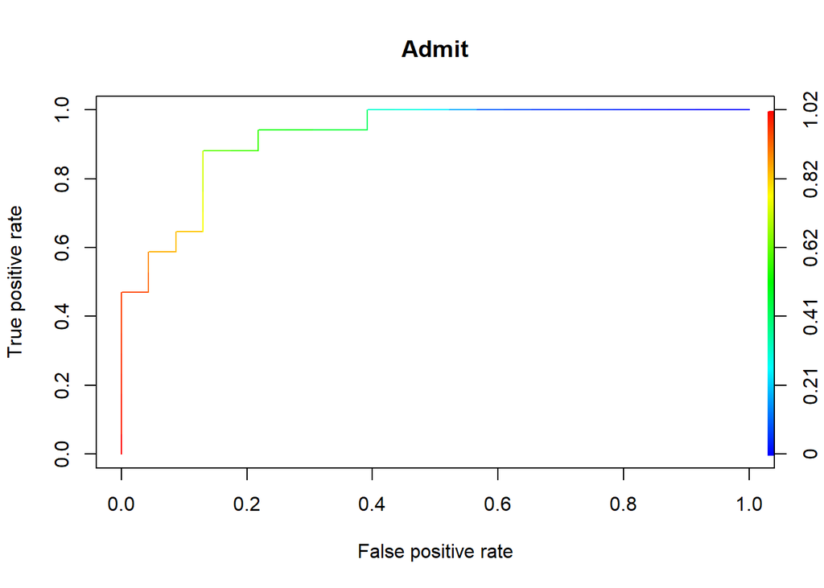

```r
indexes=sample(nrow(admission) ,replace = FALSE)
foldsIndexes = cut(indexes , breaks=10 , labels=FALSE)
indexesOfTest = which(foldsIndexes==1 , arr.ind=TRUE)
trainData=admission[-indexesOfTest,]
testData=admission[indexesOfTest,]

model=lda(Admit~.,data=trainData)
qdaPred=predict(model,testData,type = "response")
pred = prediction(qdaPred$posterior[,2], testData$Admit)
perf = performance(pred,"tpr","fpr")
plot(perf,colorize=TRUE,main="Admit")
```

## مدل QDA

```r
qdaModel=qda(Admit~.,data=admission,subset=indexOfDataTrain)
qdaModel
```

```
## Call:
## qda(Admit ~ ., data = admission, subset = indexOfDataTrain)
##
## Prior probabilities of groups:
##         0         1
## 0.5297806 0.4702194
##
## Group means:
##         PC1         PC2          PC3         PC4         PC5          PC6
## 0  1.430367 -0.11129163 -0.005238275 0.006063242 -0.00862079  0.007786459
## 1 -1.806124  0.04997214 -0.018938411 0.005027845  0.02560699 -0.017065001
##   Research1
## 0 0.3017751
## 1 0.8200000
```

```r
qdaCrossValidation=function(df,qdaModel,k){
  set.seed(100)
  indexes=sample(nrow(df) ,replace = FALSE)
  foldsIndexes = cut(indexes , breaks=k , labels=FALSE)
  v=c()
  myFormula=formula(paste(format(terms(qdaModel)),collapse = ""))

  myResponse=(as.character(attr(terms(myFormula),"variables"))[-1])[attr(terms(myFormula),"response")]
  myResponse=str_replace_all(myResponse ,"`","")
  for (i in 1:k) {
   indexesOfTest = which(foldsIndexes==i , arr.ind=TRUE)
   trainData=df[-indexesOfTest,]
   testData=df[indexesOfTest,]
   myModel=qda(formula = myFormula ,data = trainData)
   myPred=predict(ldaModel,testData)

    v[i]=sum(myPred$class==testData$Admit)/dim(testData)[1]
  }
  output=mean(v)
  return(output)
}
```

```r
qdaCrossValidation(admission,qdaModel,5)
```

```
## [1] 0.8922785
```

```r
qdaPred=predict(qdaModel,admission)
Admit=admission$Admit
qdaPreds=qdaPred$class
tableA=table(qdaPreds,Admit)
tableA
```

```
##         Admit
## qdaPreds   0   1
##        0 193  23
##        1  26 157
```

```r
truePositive=sum(admission$Admit==1 & admission$Admit==qdaPred$class)
truePositive
```

```
## [1] 157
```

```r
falsePositive=sum(admission$Admit==0 & admission$Admit!=qdaPred$class)
falsePositive
```

```
## [1] 26
```

```r
trueNegative=sum(admission$Admit==0 & admission$Admit==qdaPred$class)
trueNegative
```

```
## [1] 193
```

```r
falseNegative=sum(admission$Admit==1 & admission$Admit!=qdaPred$class)
falseNegative
```

```
## [1] 23
```

```r
precision=truePositive/(truePositive+falsePositive)
precision
```

```
## [1] 0.8579235
```

```r
recall=truePositive/(truePositive+falseNegative)
recall
```

```
## [1] 0.8722222
```

اکنون ROC را برای qda رسم میکنیم.

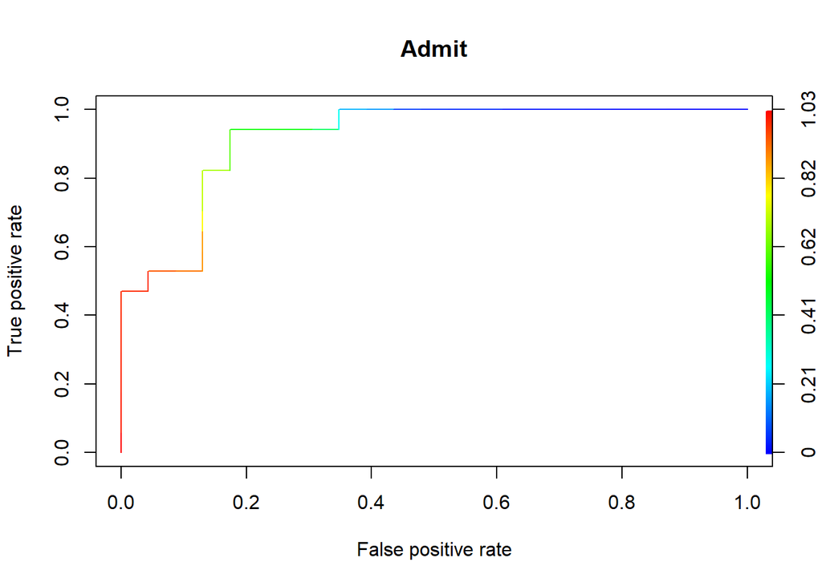

```r
indexes=sample(nrow(admission) ,replace = FALSE)
foldsIndexes = cut(indexes , breaks=10 , labels=FALSE)
indexesOfTest = which(foldsIndexes==1 , arr.ind=TRUE)
trainData=admission[-indexesOfTest,]
testData=admission[indexesOfTest,]

model=qda(Admit~.,data=trainData)
qdaPred=predict(model,testData,type = "response")
pred = prediction(qdaPred$posterior[,2], testData$Admit)
perf = performance(pred,"tpr","fpr")
plot(perf,colorize=TRUE,main="Admit")
```